# homework 4

The link to my github repository: [homework 4](https://github.com/snuuym/stats506/tree/main/homework%204)

## Problem 1

```r
library(dplyr)
library(tidyr)
library(nzelect)
data("nzge")
```

### a.

Generate a table (which can just be a nicely printed tibble) of vote count (regardless of party) per year/type. Make sure to sort it by vote count.

```r
vote_table <-
    nzge %>%
    group_by(voting_type, election_year) %>%
    summarise(total_votes = sum(votes)) %>%
    arrange(desc(total_votes))
vote_table
```

```
# A tibble: 10 × 3
# Groups:   voting_type [2]
   voting_type election_year total_votes
   <chr>               <dbl>       <dbl>
 1 Party                2014     2416479
 2 Candidate            2014     2375493
 3 Party                2008     2356536
 4 Candidate            2008     2325598
 5 Party                2005     2286190
 6 Candidate            2005     2260670
 7 Party                2011     2257336
 8 Candidate            2011     2225766
 9 Party                2002     2040248
10 Candidate            2002     2022115
```

### b.

Focus only on the 2014 election. Report the proportion of votes for each party in the Candidate election. Again, produce a nice table and sort it by percent of vote.

```r
vote_2014 <-
    nzge %>%
    filter(election_year == 2014, voting_type == "Candidate") %>%
    group_by(party) %>%
    summarise(party_vote = sum(votes)) %>%
    mutate(percent_vote = 100 * party_vote / sum(party_vote)) %>%
    arrange(desc(party_vote))

vote_2014
```

```
# A tibble: 25 × 3
   party                    party_vote percent_vote
   <chr>                         <dbl>        <dbl>
 1 National Party              1081787       45.5
 2 Labour Party                 801287       33.7
 3 Green Party                  165718        6.98
 4 Conservative Party            81075        3.41
 5 New Zealand First Party       73384        3.09
 6 Maori Party                   42108        1.77
 7 MANA Movement                 32333        1.36
 8 Informal Candidate Votes      27886        1.17
 9 ACT New Zealand               27778        1.17
10 United Future                 14722        0.620
# ℹ 15 more rows
```

### c.

Produce a nice table indicating, for each year, which party won the Candidate vote and which party won the Party vote.

```r
#chatgpt taught me the way to select the max value
party_won <-
    nzge %>%
    group_by(party, election_year, voting_type) %>%
    summarise(party_vote = sum(votes)) %>%
    group_by(election_year, voting_type) %>%
    slice_max(order_by = party_vote, n = 1) %>%
    arrange(election_year)
party_won
```

```
# A tibble: 10 × 4
# Groups:   election_year, voting_type [10]
   party          election_year voting_type party_vote
   <chr>                  <dbl> <chr>            <dbl>
 1 Labour Party            2002 Candidate       891866
 2 Labour Party            2002 Party           838219
 3 National Party          2005 Candidate       902874
 4 Labour Party            2005 Party           935319
 5 National Party          2008 Candidate      1072024
 6 National Party          2008 Party          1053398
 7 National Party          2011 Candidate      1027696
 8 National Party          2011 Party          1058636
 9 National Party          2014 Candidate      1081787
10 National Party          2014 Party          1131501
```

## Problem 2

```r
data <- read.csv("https://raw.githubusercontent.com/JeffSackmann/tennis_atp/refs/heads/master/atp_matches_2019.csv")
head(data)
```

```
  tourney_id tourney_name surface draw_size tourney_level tourney_date
1  2019-M020     Brisbane    Hard        32             A     20181231
2  2019-M020     Brisbane    Hard        32             A     20181231
3  2019-M020     Brisbane    Hard        32             A     20181231
4  2019-M020     Brisbane    Hard        32             A     20181231
5  2019-M020     Brisbane    Hard        32             A     20181231
6  2019-M020     Brisbane    Hard        32             A     20181231
  match_num winner_id winner_seed winner_entry        winner_name winner_hand
1       300    105453           2                   Kei Nishikori           R
2       299    106421           4                 Daniil Medvedev           R
3       298    105453           2                   Kei Nishikori           R
4       297    104542          NA           PR Jo-Wilfried Tsonga           R
5       296    106421           4                 Daniil Medvedev           R
6       295    104871          NA                   Jeremy Chardy           R
  winner_ht winner_ioc winner_age loser_id loser_seed loser_entry
```

[output cut: 41 more lines]

```r
colnames(data)
```

```
 [1] "tourney_id"         "tourney_name"       "surface"
 [4] "draw_size"          "tourney_level"      "tourney_date"
 [7] "match_num"          "winner_id"          "winner_seed"
[10] "winner_entry"       "winner_name"        "winner_hand"
[13] "winner_ht"          "winner_ioc"         "winner_age"
[16] "loser_id"           "loser_seed"         "loser_entry"
[19] "loser_name"         "loser_hand"         "loser_ht"
[22] "loser_ioc"          "loser_age"          "score"
[25] "best_of"            "round"              "minutes"
[28] "w_ace"              "w_df"               "w_svpt"
[31] "w_1stIn"            "w_1stWon"           "w_2ndWon"
[34] "w_SvGms"            "w_bpSaved"          "w_bpFaced"
[37] "l_ace"              "l_df"               "l_svpt"
[40] "l_1stIn"            "l_1stWon"           "l_2ndWon"
[43] "l_SvGms"            "l_bpSaved"          "l_bpFaced"
[46] "winner_rank"        "winner_rank_points" "loser_rank"
[49] "loser_rank_points"
```

### a.

How many tournaments took place in 2019?

```r
library(dplyr)
library(tidyr)
data %>%
  filter(substr(tourney_date, 1, 4) == "2019") %>%
  summarise(total_tournaments = n_distinct(tourney_id))
```

```
  total_tournaments
1               125
```

### b.

Did any player win more than one tournament? If so, how many players won more than one tournament, and how many tournaments did the most winning player(s) win?

```r
winners <- data %>%
  filter(round == "F") %>%
  group_by(winner_id) %>%
  summarise(total_win = n_distinct(tourney_id)) %>%
  filter(total_win > 1) %>%
  arrange(desc(total_win))
```

### c.

Is there any evidence that winners have more aces than losers?

```r
library(dplyr)
library(infer)
data %>% select(w_ace, l_ace) %>%
  mutate(diff = w_ace - l_ace) %>%
  t_test(response = diff, mu = 0)
```

```
# A tibble: 1 × 7
  statistic  t_df  p_value alternative estimate lower_ci upper_ci
      <dbl> <dbl>    <dbl> <chr>          <dbl>    <dbl>    <dbl>
1      12.4  2693 3.06e-34 two.sided       1.70     1.43     1.98
```

Ans: From the estimate value and the p-value of the t-test we can say that there is evidence that winners have more aces than losers.

### d.

Identify the player(s) with the highest win-rate. (Note that this is NOT asking for the highest number of wins.) Restrict to players with at least 5 matches.

```r
player <- data %>%
  select(winner_id, loser_id, winner_name, loser_name, tourney_id) %>%
  pivot_longer(cols = c(winner_id, loser_id),
               names_to = "match_result",
               values_to = "player_id") %>%
  mutate(player_name = if_else(match_result == "winner_id",
                               winner_name,
                               loser_name)) %>%
  group_by(player_id, player_name) %>%
  summarise(total_matches = n())
match_win <- data %>%
  group_by(winner_id, winner_name) %>%
  summarise(total_win = n())
player_stats <- player %>%
  left_join(match_win, join_by("player_id" == "winner_id", "player_name" == "winner_name")) %>%
  mutate(total_win = replace_na(total_win, 0),
         win_rate = total_win / total_matches) %>%
  filter(total_matches >= 5) %>%
  arrange(desc(win_rate))
head(player_stats,5)
```

```
# A tibble: 5 × 5
# Groups:   player_id [5]
  player_id player_name     total_matches total_win win_rate
      <int> <chr>                   <int>     <int>    <dbl>
1    104745 Rafael Nadal               69        60    0.870
2    104925 Novak Djokovic             69        58    0.841
3    103819 Roger Federer              66        55    0.833
4    106421 Daniil Medvedev            80        59    0.738
5    104731 Kevin Anderson             15        11    0.733
```

Ans: Rafael Nadal has the highest winning rate.

## Problem 3

```r
data <- read.csv("https://raw.githubusercontent.com/nytimes/covid-19-data/refs/heads/master/rolling-averages/us-states.csv")
head(data)
```

```
        date  geoid      state cases cases_avg cases_avg_per_100k deaths
1 2020-01-21 USA-53 Washington     1      0.14                  0      0
2 2020-01-22 USA-53 Washington     0      0.14                  0      0
3 2020-01-23 USA-53 Washington     0      0.14                  0      0
4 2020-01-24 USA-53 Washington     0      0.14                  0      0
5 2020-01-24 USA-17   Illinois     1      0.14                  0      0
6 2020-01-25 USA-53 Washington     0      0.14                  0      0
  deaths_avg deaths_avg_per_100k
1          0                   0
2          0                   0
3          0                   0
4          0                   0
5          0                   0
6          0                   0
```

```r
colnames(data)
```

```
[1] "date"                "geoid"               "state"
[4] "cases"               "cases_avg"           "cases_avg_per_100k"
[7] "deaths"              "deaths_avg"          "deaths_avg_per_100k"
```

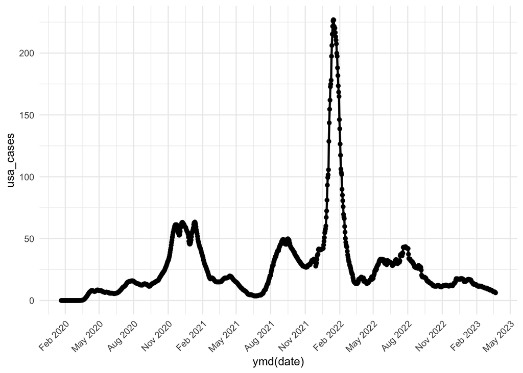

```r
#chatgpt taught me how to use ymd() to change date into date type so that it can be further manipulated.
library(ggplot2)
library(lubridate)
covid <- data %>%
  group_by(date) %>%
  summarise(usa_cases = mean(cases_avg_per_100k))

ggplot(covid, aes(x = ymd(date), y = usa_cases)) +
  geom_line(linewidth = 1) +
  geom_point() +
  scale_x_date(
    date_breaks = "3 months",
    date_labels = "%b %Y"
  )+
  theme_minimal() +
  theme(
    axis.text.x = element_text(angle = 45, hjust = 1)
  )
```

Ans: There is 1 major spike and 3 minor spikes there.

### b.

For the states with the highest and lowest overall rates per population, what differences do you see in their trajectories over time?

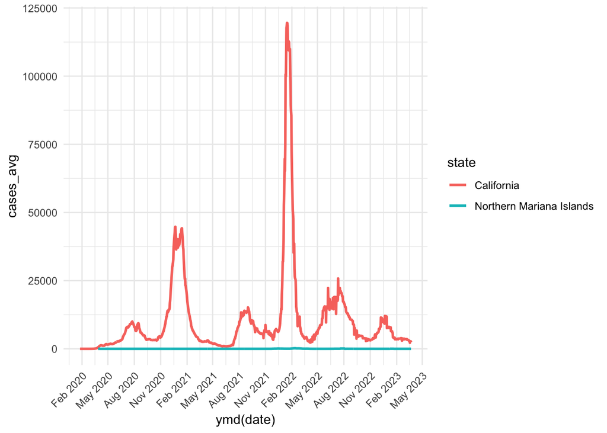

```r
states <- data %>%
  group_by(state) %>%
  summarise(overall_rate = mean(cases_avg,na.rm = TRUE))
high_state <- states %>% slice_max(overall_rate, n = 1) %>% pull(state)
low_state  <- states %>% slice_min(overall_rate, n = 1) %>% pull(state)

prob_b <- data %>%
  filter(state %in% c(high_state,low_state))

ggplot(prob_b, aes(x = ymd(date), y = cases_avg, color = state, group = state)) +
  geom_line(linewidth=1)  +
    scale_x_date(
    date_breaks = "3 months",
    date_labels = "%b %Y"
  )+
  theme_minimal() +
  theme(
    axis.text.x = element_text(angle = 45, hjust = 1)
  )
```

### c.

Identify, to the best of your ability without a formal test, the first five states to experience Covid in a substantial way.

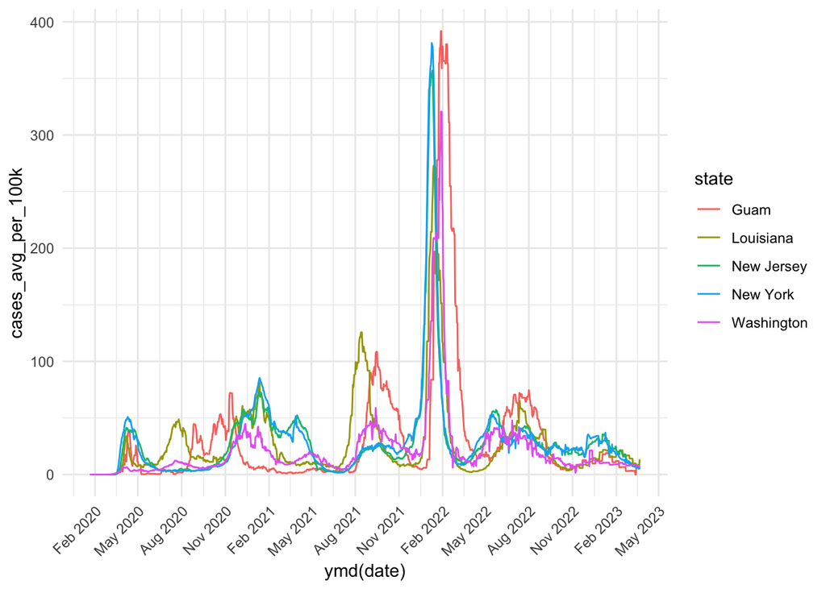

```r
first_wave <- data %>%
  filter(cases_avg_per_100k > 1) %>%
  group_by(state) %>%
  summarize(first_date = min(date)) %>%
  arrange(first_date) %>%
  slice_head(n = 5)

first_states <- first_wave$state


data %>%
  filter(state %in% first_states) %>%
  ggplot(aes(x = ymd(date), y = cases_avg_per_100k, color = state,group = state)) +
  geom_line(linewidth=0.5)  +
    scale_x_date(
    date_breaks = "3 months",
    date_labels = "%b %Y"
  )+
  theme_minimal() +
  theme(
    axis.text.x = element_text(angle = 45, hjust = 1)
  )
```